# Progress Memo 1

Final Project  
Data Science 1 with R (STAT 301-1)

Author

Claire Derksen

Published

October 27, 2023

**Github Repo Link**

https://github.com/stat301-1-2023-fall/final-project-1-cadaora

## Data source

I am using data from the National Survey on Drug Use and Health (NSDUH) for 2020[^1] and 2019[^2]. It is a survey conducted by the Substance Abuse and Mental Health Administration (SAMSHA) of people aged 12 and older in the United States. It covers topics including mental health and substance use. Due to methodology changes including web-based interviewing, the 2020 and 2019 NSDUH data may be hard to compare. However, SAMSHA provided a comparability chart that shows what variables are comparable between 2019 and 2020. I will use the comparability chart to merge the two data sets.

## Why this data

I’m interested in exploring what societal factors can impact drug use. I’d like to particularly focus on college students since that’s applicable to my life. It’d be interesting to see if there was any particular increase in drug use during the start of the COVID-19 pandemic caused by the isolation of quarantine. Since the survey also tracks mental health topics I could also explore any changes in the mental health of college students during the pandemic.

## Data quality & complexity check

Most of the variables are integers that would need to be interpreted using the code book. The original 2020 file had 32893 observations and 2890 variables. The previous year, 2019, had 56136 observations and 2741 variables. After filtering only college students we had 3337 observations in the 2020 dataset and 6136 observations in the 2019 dataset.

I started with assessing missingness in the 2020 college dataset.

```
# A tibble: 10 × 3
   variable n_miss pct_miss
   <chr>     <int>    <dbl>
 1 SIMHSUI2   3337      100
 2 SIMHDPR2   3337      100
 3 SIMHFEA2   3337      100
 4 SIMHBRK2   3337      100
 5 SIMHEAT2   3337      100
 6 SIMHANG2   3337      100
 7 SIMHFIT2   3337      100
 8 SIMHFML2   3337      100
 9 SIMHFRD2   3337      100
10 SIMHOTP2   3337      100
```

Just looking at missingness there seems to be a considerable amount of data missing. However, looking at the codebook helps us understand why certain variables have no data.

```
# A tibble: 10 × 3
   variable   n_miss pct_miss
   <chr>       <int>    <dbl>
 1 SRCFRSEDNM   3331     99.8
 2 SRCCLFRSED   3331     99.8
 3 NDTRNNOCOV   3327     99.7
 4 NDTRNNOTPY   3327     99.7
 5 NDTRNTSPHR   3327     99.7
 6 NDTRNWANTD   3327     99.7
 7 NDTRNNSTOP   3327     99.7
 8 NDTRNPFULL   3327     99.7
 9 NDTRNDKWHR   3327     99.7
10 NDTRNNBRNG   3327     99.7
```

The 2020 codebook reveals the variables at or near 100% missingness were reserved for people under 18, so our data set of college students will have little to no values for those variables. For the remaining variables with a high proportion of missingness I will have to look through the code book in order to determine whether the data is worth keeping.

One variable I could easily explore that I know I will be using is EDUSCHGRD2. From this we can see the proportion of different years in college in our 2020 dataset.

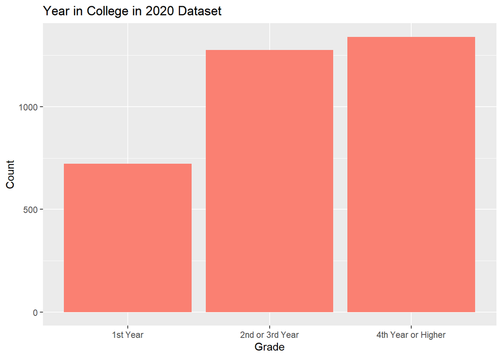

## Potential data issues

In order to eliminate non-comparable variables I imported the excel comparability column for 2019-2020 using readxl and converted it into a list. After removing the non-comparable variables, there were still many variables with a high portion of missingness. I decided to continue looking through the codebook to decipher why they are missing.

Many of the variables with high missingness are only asked for people who said they did use a specific drug. So if the majority of people answered no in a previous question asking about the drug, the later relevant question will have a majority NA values. I should be able to fix this later once I convert the integer values to factor values. Examples of this are questions asking about the source of a drug (variables starting with SRC) or questions only asked to smokers(CIG_). One challenge is that many variables code legitimate skips and unknowns together in NA so I’m unsure of whether I should replace the NA. The values around 72% missing starting with A are questions relating to adults diagnosed with depression so I will keep those variables for analysis.

I decided to get rid of the questions asking about drug treatment/rehab since I wanted to focus more on drug use and very few college students had been to rehab in the past year. I also got rid of nicotine dependence scores, questions specific to underage drinking(UAD…), and adult mental health service utilization (AU_,AMH_,MH_,RCV_).

```
     variable n_miss pct_miss
1  SRCFRSEDNM   3331 99.82020
2  SRCCLFRSED   3331 99.82020
3  SRCFRPNRNM   3306 99.07102
4  SRCCLFRPNR   3306 99.07102
5  SRCFRTRQNM   3297 98.80132
6  SRCCLFRTRQ   3297 98.80132
7  SRCFRSTMNM   3257 97.60264
8  SRCCLFRSTM   3257 97.60264
9    CIG1PACK   3235 96.94336
10    CIGAVGD   3024 90.62032
11    CIGAVGM   3024 90.62032
12   ASDSHOM2   2765 82.85886
13   ASDSWRK2   2765 82.85886
14   ASDSREL2   2765 82.85886
15   ASDSSOC2   2765 82.85886
16   ASDSOVL2   2765 82.85886
17    AOTHMDE   2439 73.08960
18    ADOCMDE   2435 72.96973
19    AOMDMDE   2435 72.96973
20   APSY1MDE   2435 72.96973
21   APSY2MDE   2435 72.96973
22    ASOCMDE   2435 72.96973
23   ACOUNMDE   2435 72.96973
```

ALCNUMDKPM refers to whether the number of drinks in the past month was >0. Meaning that if the value is NA it is either no or unknown. I’ll reassess missingness after I’m able to convert the variables to factors. The standard code conventions on page 31 of the 2020 codebook will be helpful in converting the variables and hopefully there are only a few exceptions to the convention.

One issue I encountered while working with the data set was processing time. It takes a long time for the >100MB .txt files to load. I solved this by creating two new .rds files for each year only containing college students in order to shorten future loading times.

## Misc

My plan is to apply the comparability chart to the 2019 and remove the unwanted variables. After that I will confirm that it has the same variables as the 2020 dataset and combine them. From there I will apply the standard code conventions to convert the variables to factors as well as address some of the values with a high missingness proportion.

I’d also like to use the janitor package to make the names lowercase and start to focus in on what variables are most of interest.

## Footnotes

[^1]: https://www.datafiles.samhsa.gov/dataset/national-survey-drug-use-and-health-2020-nsduh-2020-ds0001
[^2]: https://www.datafiles.samhsa.gov/dataset/national-survey-drug-use-and-health-2019-nsduh-2019-ds0001